# Reproducible_Research Project 1

YL Chang

Monday, May 11, 2015

## Loading and preprocessing the data

The following code chunk reads the data and store them in 3 arrays.

```r
data <- read.csv("activity.csv")
steps <-data$steps
date <- data$date
interval <-data$interval
```

## What is mean total number of steps taken per day?

Calculate the total number of steps taken per day. This is done by using the “tapply” function.

```r
stepdate<-tapply(steps, date, sum, na.rm = TRUE)
```

Make a histogram of the total number of steps taken each day

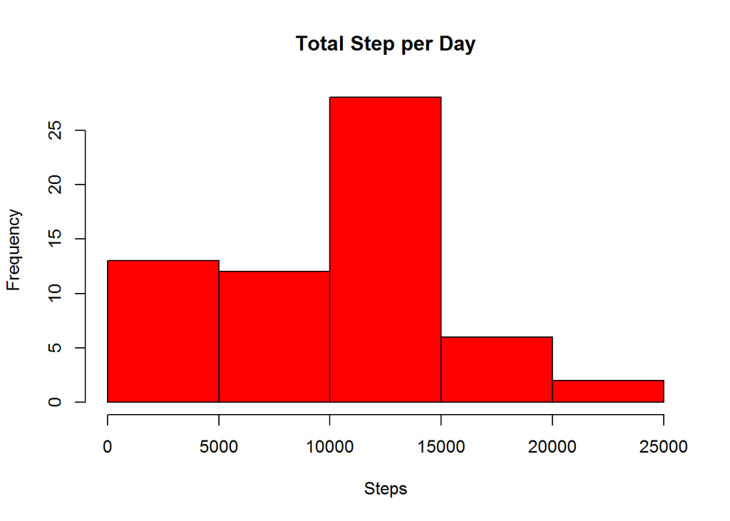

```r
hist(stepdate, main = "Total Step per Day",xlab = "Steps", col = "red")
```

This distribution is skewed to the left. This is because that there are a lot of NA in the original data set.

Calculate and report the mean and median of the total number of steps taken per day

```r
mean(stepdate)
```

```
## [1] 9354.23
```

```r
median(stepdate)
```

```
## [1] 10395
```

## What is the average daily activity pattern?

Make a time series plot (i.e. type = “l”) of the 5-minute interval (x-axis) and the average number of steps taken, averaged across all days (y-axis)

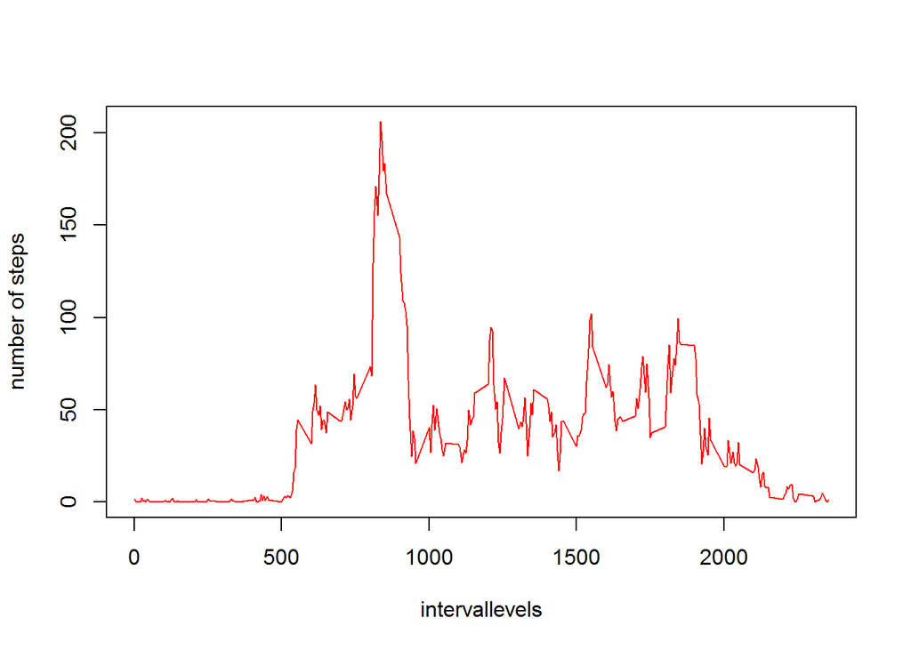

```r
stepinterval<-tapply(steps, interval, mean, na.rm = TRUE)
intervallevels <- levels(factor(interval))
plot(stepinterval~intervallevels,type = "l", ylab = "number of steps", col = "red")
```

Which 5-minute interval, on average across all the days in the dataset, contains the maximum number of steps?

```r
intervallevels[which.max(stepinterval)]
```

```
## [1] "835"
```

## Imputing missing values

Calculate and report the total number of missing values in the dataset

```r
sum(is.na(steps))
```

```
## [1] 2304
```

Devise a strategy for filling in all of the missing values in the dataset. Using mean of the 5-minute intervals.

```r
newsteps <- steps
meanstepinterval<-tapply(newsteps, interval, mean, na.rm = TRUE)
```

Create a new dataset that is equal to the original dataset but with the missing data filled in.

```r
ind <- which( is.na( newsteps ) )
for (i in 1:length(ind)){
    k <- ind[i]%%dim(meanstepinterval)
    if(k == 0) {
      newsteps[ind[i]] <- meanstepinterval[dim(meanstepinterval)]
    } else {
      newsteps[ind[i]] <- meanstepinterval[k]
    }
}
```

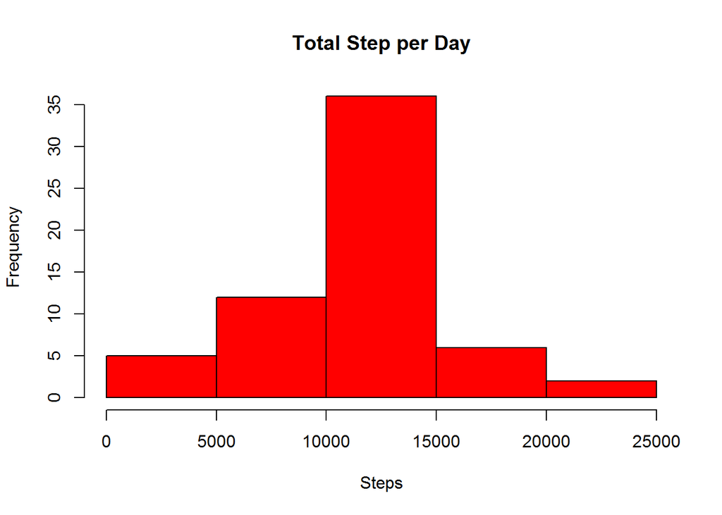

```r
newstepdate<-tapply(newsteps, date, sum, na.rm = TRUE)
hist(newstepdate, main = "Total Step per Day",xlab = "Steps", col = "red")
```

After imputing the missing values by using the mean of the 5-minute interval accross all dates, the skewed distribution become more normal.

Calculate and report the mean and median total number of steps taken per day.

```r
mean(newstepdate)
```

```
## [1] 10766.19
```

```r
median(newstepdate)
```

```
## [1] 10766.19
```

## Are there differences in activity patterns between weekdays and weekends?

```r
weekdaydata <- weekdays(as.Date(date,"%m/%d/%Y"))
WDWE<-rep("weekday", each = length(weekdaydata))
WDWE[which(weekdaydata == "Saturday" | weekdaydata == "Sunday")] <- "weekend"
```

Make a panel plot containing a time series plot (i.e. type = “l”) of the 5-minute interval (x-axis) and the average number of steps taken, averaged across all weekday days or weekend days (y-axis).

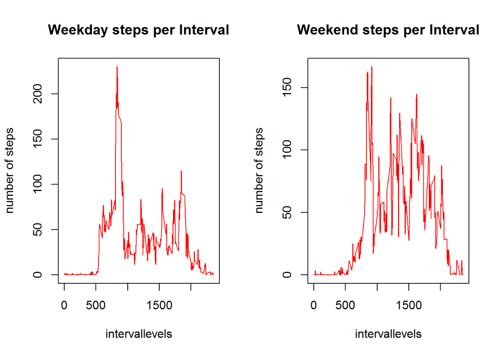

```r
splitnewsteps<-split(newsteps,WDWE)
splitinterval<-split(interval,WDWE)

splitnewstepintervalWD<-tapply(splitnewsteps$weekday, splitinterval$weekday, mean, na.rm = TRUE)
splitnewstepintervalWE<-tapply(splitnewsteps$weekend, splitinterval$weekend, mean, na.rm = TRUE)

par(mfrow = c(1, 2))
    plot(splitnewstepintervalWD~intervallevels,type = "l",col = "red", ylab = "number of steps", main = "Weekday steps per Interval")
    plot(splitnewstepintervalWE~intervallevels,type = "l",col = "red", ylab = "number of steps", main = "Weekend steps per Interval")
```

It can be seen from the plots that this test object is more active in the weekend than in the weekday.